# Actividad 2 Modulo 1

### *Modelo no espacial de efectos fijos y aleatorios con transformaciones*

Se busca utilizar transformaciones logarítmicas para saber si mejora el resultado.

```r
no_espacial_fetime_1<-plm(new_fdi_real_mxn ~ real_wage + log(pop_density) + region_b + log(lq_primary) + employment, data=nearshoring_pd, model="within", effect="time")
summary(no_espacial_fetime_1)
```

```
## Oneway (time) effect Within Model
##
## Call:
## plm(formula = new_fdi_real_mxn ~ real_wage + log(pop_density) +
##     region_b + log(lq_primary) + employment, data = nearshoring_pd,
##     effect = "time", model = "within")
##
## Balanced Panel: n = 32, T = 16, N = 512
##
## Residuals:
##      Min.   1st Qu.    Median   3rd Qu.      Max.
## -44529.37  -4172.40   -585.48   2709.92  59672.82
##
## Coefficients:
##                    Estimate Std. Error t-value  Pr(>|t|)
## real_wage            76.019     10.971  6.9289 1.337e-11 ***
## log(pop_density)   1962.571    353.493  5.5519 4.632e-08 ***
## region_b             42.416    309.923  0.1369    0.8912
## log(lq_primary)   -1927.211    460.942 -4.1810 3.437e-05 ***
## employment       -40747.053  29929.097 -1.3615    0.1740
## ---
## Signif. codes:  0 '***' 0.001 '**' 0.01 '*' 0.05 '.' 0.1 ' ' 1
##
## Total Sum of Squares:    5.3102e+10
## Residual Sum of Squares: 3.2824e+10
## R-Squared:      0.38187
## Adj. R-Squared: 0.35669
## F-statistic: 60.6655 on 5 and 491 DF, p-value: < 2.22e-16
```

```r
no_espacial_fetime_2<-plm(new_fdi_real_mxn ~ real_wage + log(pop_density) + region_b + lq_primary + employment, data=nearshoring_pd, model="within", effect="time")
summary(no_espacial_fetime_2)
```

```
## Oneway (time) effect Within Model
##
## Call:
## plm(formula = new_fdi_real_mxn ~ real_wage + log(pop_density) +
##     region_b + lq_primary + employment, data = nearshoring_pd,
##     effect = "time", model = "within")
##
## Balanced Panel: n = 32, T = 16, N = 512
##
## Residuals:
##      Min.   1st Qu.    Median   3rd Qu.      Max.
## -40405.40  -4317.10   -764.85   2826.30  58698.58
##
## Coefficients:
##                    Estimate Std. Error t-value  Pr(>|t|)
## real_wage            96.899     10.380  9.3350 < 2.2e-16 ***
## log(pop_density)   2179.818    356.212  6.1194 1.922e-09 ***
## region_b            209.304    313.524  0.6676  0.504713
## lq_primary         -203.136    461.213 -0.4404  0.659814
## employment       -84783.113  30624.957 -2.7684  0.005846 **
## ---
## Signif. codes:  0 '***' 0.001 '**' 0.01 '*' 0.05 '.' 0.1 ' ' 1
##
## Total Sum of Squares:    5.3102e+10
## Residual Sum of Squares: 3.3979e+10
## R-Squared:      0.36011
## Adj. R-Squared: 0.33405
## F-statistic: 55.2645 on 5 and 491 DF, p-value: < 2.22e-16
```

```r
no_espacial_fetime_3<-plm(new_fdi_real_mxn ~ real_wage + pop_density + region_b + log(lq_primary) + employment, data=nearshoring_pd, model="within", effect="time")
summary(no_espacial_fetime_3)
```

```
## Oneway (time) effect Within Model
##
## Call:
## plm(formula = new_fdi_real_mxn ~ real_wage + pop_density + region_b +
##     log(lq_primary) + employment, data = nearshoring_pd, effect = "time",
##     model = "within")
##
## Balanced Panel: n = 32, T = 16, N = 512
##
## Residuals:
##      Min.   1st Qu.    Median   3rd Qu.      Max.
## -54673.51  -3570.88   -917.13   2231.04  57497.87
##
## Coefficients:
##                    Estimate  Std. Error t-value  Pr(>|t|)
## real_wage        4.6602e+01  1.0500e+01  4.4384  1.12e-05 ***
## pop_density      4.7646e+00  4.1681e-01 11.4311 < 2.2e-16 ***
## region_b        -1.3603e+02  2.5401e+02 -0.5355   0.59253
## log(lq_primary) -7.7097e+02  4.3867e+02 -1.7575   0.07945 .
## employment      -4.6659e+04  2.7427e+04 -1.7012   0.08954 .
## ---
## Signif. codes:  0 '***' 0.001 '**' 0.01 '*' 0.05 '.' 0.1 ' ' 1
##
## Total Sum of Squares:    5.3102e+10
## Residual Sum of Squares: 2.7552e+10
## R-Squared:      0.48114
## Adj. R-Squared: 0.46001
## F-statistic: 91.0628 on 5 and 491 DF, p-value: < 2.22e-16
```

## **Comparación modelos lineales**

En esta sección se comparan los mejores modelos con transformaciones logaritmicas y no logaritmicos. El modelo logaritmico fijo con efecto de tiempo en comparativa con el modelo no logaritmico fijo de tiempo.

```r
stargazer(
  no_espacial_fetime_1,
  no_espacial_fetime,
  title = "Análisis de modelos",
  type = "text",
  column.labels = c("Modelo fijo logaritmico", "Modelo fijo no logaritimico")
)
```

```
##
## Análisis de modelos
## =============================================================================
##                                           Dependent variable:
##                           ---------------------------------------------------
##                                            new_fdi_real_mxn
##                           Modelo fijo logaritmico Modelo fijo no logaritimico
##                                     (1)                       (2)
## -----------------------------------------------------------------------------
## real_wage                        76.019***                 50.588***
##                                  (10.971)                  (10.344)
##
## log(pop_density)               1,962.571***
##                                  (353.493)
##
## pop_density                                                5.004***
##                                                             (0.399)
##
## region_b                          42.416                    -95.699
##                                  (309.923)                 (253.516)
##
## log(lq_primary)                -1,927.211***
##                                  (460.942)
##
## lq_primary                                                 -353.862
##                                                            (416.518)
##
## employment                      -40,747.050              -55,661.950**
##                                (29,929.100)              (27,780.250)
##
## -----------------------------------------------------------------------------
## Observations                        512                       512
## R2                                 0.382                     0.479
## Adjusted R2                        0.357                     0.457
## F Statistic (df = 5; 491)        60.666***                 90.156***
## =============================================================================
## Note:                                             *p<0.1; **p<0.05; ***p<0.01
```

En este caso se elegira el modelo que incluye la transformación logarítmica de densidad poblacional y de lq primary ya que de esta manera se evitará obtener resultados sesgados. Es decir, el modelo fijo logaritmico.

## **Modelado datos panel espacial**

### **Creación de modelos espaciales**

Con los resultados de queen se puede observar que sí existen enlaces no nulos y un porcentaje de 13.4 de pesos no nulos. Al hacerlo con rook se encuentran 130 enlaces no nulos y un porcentaje de 12.6. A pesar de ser porcentajes relativamente bajos, se valida el por qué es importante hacer un análisis espacial.

```
## Neighbour list object:
## Number of regions: 32
## Number of nonzero links: 138
## Percentage nonzero weights: 13.47656
## Average number of links: 4.3125
## Link number distribution:
##
## 1 2 3 4 5 6 7 8 9
## 1 6 6 6 5 2 3 2 1
## 1 least connected region:
## 31 with 1 link
## 1 most connected region:
## 8 with 9 links
```

```
## Neighbour list object:
## Number of regions: 32
## Number of nonzero links: 130
## Percentage nonzero weights: 12.69531
## Average number of links: 4.0625
## Link number distribution:
##
## 1 2 3 4 5 6 7 8
## 1 6 7 7 3 4 3 1
## 1 least connected region:
## 31 with 1 link
## 1 most connected region:
## 20 with 8 links
```

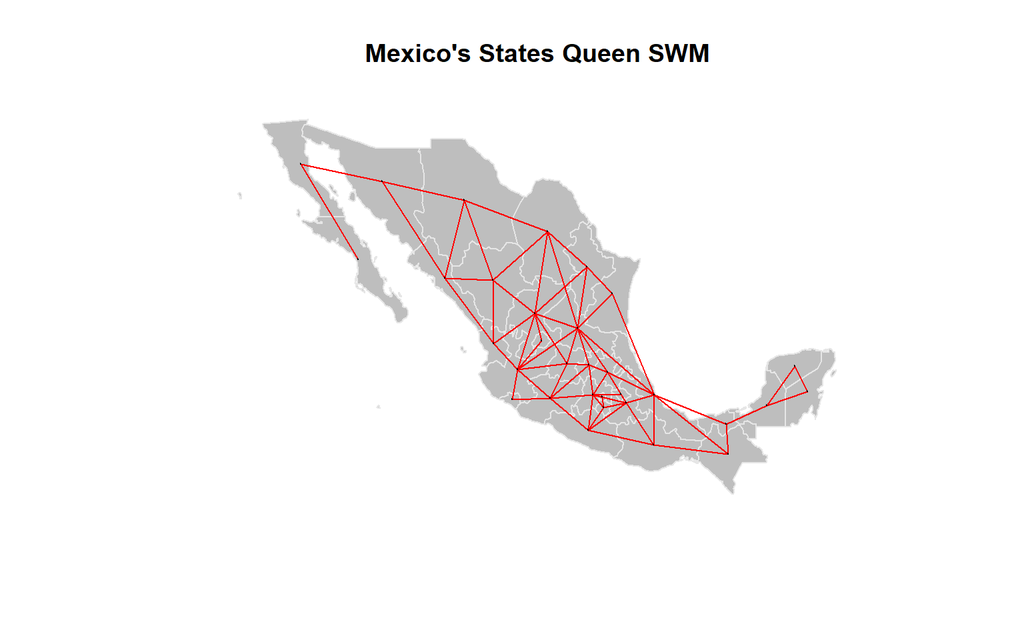

En este caso se realizo previamente pruebas moran para identificar las variables que presentan autocorrelacion espacial significativa, las variables elegidas son Real Average Month Income, Log Population Density, Log Location Quotient primary, Business activity y College education.

```r
library(splm)
panel_model<-new_fdi_real_mxn ~ real_ave_month_income + log(pop_density) + log(lq_primary) + business_activity + college_education

sp_lag_real_ave <- slag(nearshoring_pd$real_ave_month_income, queen_sswm)
sp_lag_lq <- slag(nearshoring_pd$lq_primary, queen_sswm)
spatial_panel_model <- new_fdi_real_mxn ~ sp_lag_real_ave + log(pop_density) + log(lq_primary) + business_activity + college_education
spatial_panel_model2 <- new_fdi_real_mxn ~ real_ave_month_income + log(pop_density) + sp_lag_lq + business_activity + college_education
```

### *Spatial Autorregresive Model Fijos*

```r
spatial_panel_fe <- spml(panel_model, nearshoring_pd, index = c("state","year"), queen_sswm, model= "within", effect= "time", spatial.error = "none", lag=TRUE)  # spatial autogressive
summary(spatial_panel_fe)
```

```
## Spatial panel fixed effects lag model
##
##
## Call:
## spml(formula = panel_model, data = nearshoring_pd, index = c("state",
##     "year"), listw = queen_sswm, model = "within", effect = "time",
##     lag = TRUE, spatial.error = "none")
##
## Residuals:
##      Min.   1st Qu.    Median   3rd Qu.      Max.
## -43330.47  -4408.30   -890.91   2918.53  64956.30
##
## Spatial autoregressive coefficient:
##        Estimate Std. Error t-value Pr(>|t|)
## lambda 0.008111   0.051403  0.1578   0.8746
##
## Coefficients:
##                          Estimate  Std. Error t-value  Pr(>|t|)
## real_ave_month_income     0.20416     0.49534  0.4121   0.68023
## log(pop_density)       2844.57794   365.48780  7.7830 7.085e-15 ***
## log(lq_primary)       -3255.91402   447.92777 -7.2688 3.626e-13 ***
## business_activity      1038.80927   458.63174  2.2650   0.02351 *
## college_education      1691.59082  8563.48939  0.1975   0.84341
## ---
## Signif. codes:  0 '***' 0.001 '**' 0.01 '*' 0.05 '.' 0.1 ' ' 1
```

El modelo no es estadísticamente significativo, indicando la falta de autocorrelación espacial en los residuales. De cualquier manera, se encuentran significativas las variables del logaritmo de densidad de población, el logaritmo de location quotient primario y la actividad de negocios. Indicando que estas tienen efectos significativos en la variable dependiente.

### *Spatial Autorregresive Model Random*

```r
spatial_panel_fe2 <- spml(panel_model, nearshoring_pd, index = c("state","year"), queen_sswm, model= "random", spatial.error = "none", lag=TRUE)  # spatial autogressive
summary(spatial_panel_fe)
```

```
## Spatial panel fixed effects lag model
##
##
## Call:
## spml(formula = panel_model, data = nearshoring_pd, index = c("state",
##     "year"), listw = queen_sswm, model = "within", effect = "time",
##     lag = TRUE, spatial.error = "none")
##
## Residuals:
##      Min.   1st Qu.    Median   3rd Qu.      Max.
## -43330.47  -4408.30   -890.91   2918.53  64956.30
##
## Spatial autoregressive coefficient:
##        Estimate Std. Error t-value Pr(>|t|)
## lambda 0.008111   0.051403  0.1578   0.8746
##
## Coefficients:
##                          Estimate  Std. Error t-value  Pr(>|t|)
## real_ave_month_income     0.20416     0.49534  0.4121   0.68023
## log(pop_density)       2844.57794   365.48780  7.7830 7.085e-15 ***
## log(lq_primary)       -3255.91402   447.92777 -7.2688 3.626e-13 ***
## business_activity      1038.80927   458.63174  2.2650   0.02351 *
## college_education      1691.59082  8563.48939  0.1975   0.84341
## ---
## Signif. codes:  0 '***' 0.001 '**' 0.01 '*' 0.05 '.' 0.1 ' ' 1
```

### Hausman Test:

```r
sphtest(spatial_panel_fe, spatial_panel_fe2)
```

```
##
##  Hausman test for spatial models
##
## data:  panel_model
## chisq = 28.16, df = 5, p-value = 3.386e-05
## alternative hypothesis: one model is inconsistent
```

El mejor modelo a elegir es el SAR de efectos fijos.

### *Spatial Error Model Fijo*

```r
#Spatial Error Model
spatial_panel_re <- spml(panel_model, data = nearshoring_pd, index = c("state","year"), queen_sswm, model="within", spatial.error="b", lag=FALSE) # spatial autoregressive
summary(spatial_panel_re)
```

```
## Spatial panel fixed effects error model
##
##
## Call:
## spml(formula = panel_model, data = nearshoring_pd, index = c("state",
##     "year"), listw = queen_sswm, model = "within", lag = FALSE,
##     spatial.error = "b")
##
## Residuals:
##      Min.   1st Qu.    Median   3rd Qu.      Max.
## -56007.34  -2535.12   -644.53   1524.70  51293.64
##
## Spatial error parameter:
##     Estimate Std. Error t-value Pr(>|t|)
## rho 0.150511   0.056284  2.6741 0.007493 **
##
## Coefficients:
##                          Estimate  Std. Error t-value Pr(>|t|)
## real_ave_month_income     0.83518     0.80794  1.0337  0.30127
## log(pop_density)        625.52120 10064.92203  0.0621  0.95044
## log(lq_primary)        2137.94540   907.06876  2.3570  0.01842 *
## business_activity      3978.64362  4090.63232  0.9726  0.33074
## college_education     -5481.56119 10375.64422 -0.5283  0.59728
## ---
## Signif. codes:  0 '***' 0.001 '**' 0.01 '*' 0.05 '.' 0.1 ' ' 1
```

### *Spatial Error Model Random*

```r
#Spatial Error Model
spatial_panel_re2 <- spml(panel_model, data = nearshoring_pd, index = c("state","year"), queen_sswm, model="random", spatial.error="b", lag=FALSE) # spatial autoregressive
summary(spatial_panel_re)
```

```
## Spatial panel fixed effects error model
##
##
## Call:
## spml(formula = panel_model, data = nearshoring_pd, index = c("state",
##     "year"), listw = queen_sswm, model = "within", lag = FALSE,
##     spatial.error = "b")
##
## Residuals:
##      Min.   1st Qu.    Median   3rd Qu.      Max.
## -56007.34  -2535.12   -644.53   1524.70  51293.64
##
## Spatial error parameter:
##     Estimate Std. Error t-value Pr(>|t|)
## rho 0.150511   0.056284  2.6741 0.007493 **
##
## Coefficients:
##                          Estimate  Std. Error t-value Pr(>|t|)
## real_ave_month_income     0.83518     0.80794  1.0337  0.30127
## log(pop_density)        625.52120 10064.92203  0.0621  0.95044
## log(lq_primary)        2137.94540   907.06876  2.3570  0.01842 *
## business_activity      3978.64362  4090.63232  0.9726  0.33074
## college_education     -5481.56119 10375.64422 -0.5283  0.59728
## ---
## Signif. codes:  0 '***' 0.001 '**' 0.01 '*' 0.05 '.' 0.1 ' ' 1
```

### Hausman Test:

```r
sphtest(spatial_panel_re, spatial_panel_re2)
```

```
##
##  Hausman test for spatial models
##
## data:  panel_model
## chisq = 20.753, df = 5, p-value = 0.0009017
## alternative hypothesis: one model is inconsistent
```

El mejor modelo es el SEM de efectos fijos.

### *Durbin*

#### *Durbin fijos*

```r
#Durbin
spatial_panel_fe_a <- spml(spatial_panel_model2, nearshoring_pd, index = c("state","year"), queen_sswm, model= "within", effect= "time", spatial.error = "none", lag=TRUE)  # spatial autogressive
summary(spatial_panel_fe_a)
```

```
## Spatial panel fixed effects lag model
##
##
## Call:
## spml(formula = spatial_panel_model2, data = nearshoring_pd, index = c("state",
##     "year"), listw = queen_sswm, model = "within", effect = "time",
##     lag = TRUE, spatial.error = "none")
##
## Residuals:
##      Min.   1st Qu.    Median   3rd Qu.      Max.
## -36782.71  -5002.79   -873.97   3063.07  64466.16
##
## Spatial autoregressive coefficient:
##        Estimate Std. Error t-value Pr(>|t|)
## lambda 0.034981   0.055455  0.6308   0.5282
##
## Coefficients:
##                         Estimate Std. Error t-value  Pr(>|t|)
## real_ave_month_income 8.3933e-01 5.1183e-01  1.6399  0.101031
## log(pop_density)      3.8838e+03 3.5055e+02 11.0793 < 2.2e-16 ***
## sp_lag_lq             1.8068e+03 8.2877e+02  2.1801  0.029250 *
## business_activity     1.5632e+03 4.8835e+02  3.2009  0.001370 **
## college_education     2.6989e+04 8.8259e+03  3.0580  0.002228 **
## ---
## Signif. codes:  0 '***' 0.001 '**' 0.01 '*' 0.05 '.' 0.1 ' ' 1
```

#### *Durbin aleatorios*

```r
spatial_panel_fe_a2 <- spml(spatial_panel_model2, nearshoring_pd, index = c("state","year"), queen_sswm, model= "random", spatial.error = "none", lag=TRUE)  # spatial autogressive
summary(spatial_panel_fe_a2)
```

```
## ML panel with spatial lag, random effects
##
## Call:
## spreml(formula = formula, data = data, index = index, w = listw2mat(listw),
##     w2 = listw2mat(listw2), lag = lag, errors = errors, cl = cl)
##
## Residuals:
##    Min. 1st Qu.  Median    Mean 3rd Qu.    Max.
##  -37518   -3982    -384    1131    4199   69134
##
## Error variance parameters:
##     Estimate Std. Error t-value  Pr(>|t|)
## phi  0.69669    0.19844  3.5107 0.0004468 ***
##
## Spatial autoregressive coefficient:
##        Estimate Std. Error t-value Pr(>|t|)
## lambda 0.145837   0.049931  2.9208 0.003491 **
##
## Coefficients:
##                          Estimate  Std. Error t-value  Pr(>|t|)
## (Intercept)           -1.5392e+04  6.9589e+03 -2.2118   0.02698 *
## real_ave_month_income  1.1137e+00  6.5101e-01  1.7107   0.08714 .
## log(pop_density)       4.2278e+03  8.5944e+02  4.9193 8.687e-07 ***
## sp_lag_lq              8.4312e+02  1.5764e+03  0.5348   0.59276
## business_activity      1.6866e+03  1.2314e+03  1.3696   0.17080
## college_education     -3.0048e+03  5.5759e+03 -0.5389   0.58996
## ---
## Signif. codes:  0 '***' 0.001 '**' 0.01 '*' 0.05 '.' 0.1 ' ' 1
```

### Hausman Test:

```r
sphtest(spatial_panel_fe_a, spatial_panel_fe_a2)
```

```
##
##  Hausman test for spatial models
##
## data:  spatial_panel_model2
## chisq = 10.082, df = 5, p-value = 0.07294
## alternative hypothesis: one model is inconsistent
```

El mejor modelo a elegir en este caso es el Durbin con efectos aleatorios.

### *Comparativa entre residuales de los modelos*

```r
rmsespatial_panel_fe_sar_residuals<-sqrt(mean(spatial_panel_fe_sar_residuals^2))
rmsespatial_panel_sem__residuals<-sqrt(mean(spatial_panel_sem__residuals^2))
rmsespatial_panel_fe_durbin_residuals<-sqrt(mean(spatial_panel_fe_durbin_residuals^2))
rmseno_espacial_fijoslog_residuals<-sqrt(mean(no_espacial_fijoslog_residuals^2))

rmsespatial_panel_fe_sar_residuals
```

```
## [1] 8345.153
```

```r
rmsespatial_panel_sem__residuals
```

```
## [1] 6767.709
```

```r
rmsespatial_panel_fe_durbin_residuals
```

```
## [1] 9205.815
```

```r
rmseno_espacial_fijoslog_residuals
```

```
## [1] 8006.819
```

La RMSE mas baja es del modelo SEM.

### *Comparativa entre la autocorrelacion espacial de los residuales de los modelos*

```r
spatial_panel_fe_residuals_morin <- moran.test(spatial_panel_fe_sar_residuals, listw = sswm2)
print(spatial_panel_fe_residuals_morin) #No significativo
```

```
##
##  Moran I test under randomisation
##
## data:  spatial_panel_fe_sar_residuals
## weights: sswm2
##
## Moran I statistic standard deviate = -1.8978, p-value = 0.9711
## alternative hypothesis: greater
## sample estimates:
## Moran I statistic       Expectation          Variance
##     -1.441410e-02     -1.956947e-03      4.308803e-05
```

```r
spatial_panel_re_residuals_morin<-moran.test(spatial_panel_sem__residuals, listw = sswm2)
print(spatial_panel_re_residuals_morin) #No significativo
```

```
##
##  Moran I test under randomisation
##
## data:  spatial_panel_sem__residuals
## weights: sswm2
##
## Moran I statistic standard deviate = 0.64394, p-value = 0.2598
## alternative hypothesis: greater
## sample estimates:
## Moran I statistic       Expectation          Variance
##      2.241359e-03     -1.956947e-03      4.250661e-05
```

```r
spatial_panel_fe_a_residuals_morin <- moran.test(spatial_panel_fe_durbin_residuals, listw = sswm2)
print(spatial_panel_fe_a_residuals_morin) #No significativo
```

```
##
##  Moran I test under randomisation
##
## data:  spatial_panel_fe_durbin_residuals
## weights: sswm2
##
## Moran I statistic standard deviate = -0.83909, p-value = 0.7993
## alternative hypothesis: greater
## sample estimates:
## Moran I statistic       Expectation          Variance
##     -7.473871e-03     -1.956947e-03      4.322894e-05
```

```r
spatial_panel_fe_a2_residuals_morin<-moran.test(no_espacial_fijoslog_residuals, listw = sswm2)
print(spatial_panel_fe_a2_residuals_morin) #Significativo
```

```
##
##  Moran I test under randomisation
##
## data:  no_espacial_fijoslog_residuals
## weights: sswm2
##
## Moran I statistic standard deviate = 12.993, p-value < 2.2e-16
## alternative hypothesis: greater
## sample estimates:
## Moran I statistic       Expectation          Variance
##      0.0834040907     -0.0019569472      0.0000431627
```

## **Modelado Machine learning**

### Creacion de modelo machine learning

En este caso se decidio utilizar el modelo de regresion de decision trees.

```r
# Create a decision tree model specification
tree_spec <- decision_tree() %>%
 set_engine("rpart") %>%
 set_mode("regression")

# Fit the model to the training data
tree_fit <- tree_spec %>%
 fit(new_fdi_real_mxn ~ real_wage + pop_density + region_b + lq_primary + employment, data = train_data)
```

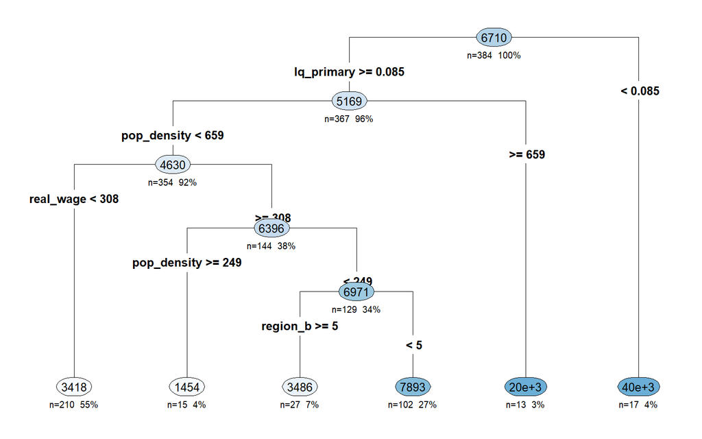

```r
# Load the library
library(rpart.plot)

# Plot the decision tree
rpart.plot(tree_fit$fit, type = 4, extra = 101, under = TRUE, cex = 0.8, box.palette = "auto")
```

```r
predictions <- tree_fit %>%
 predict(nearshoring) %>%
 pull(.pred)

# Calculate RMSE and R-squared
metrics <- metric_set(rmse, rsq)
model_performance <- nearshoring %>%
 mutate(predictions = predictions) %>%
 metrics(truth = new_fdi_real_mxn, estimate = predictions)

print(model_performance)
```

```
## # A tibble: 2 × 3
##   .metric .estimator .estimate
##   <chr>   <chr>          <dbl>
## 1 rmse    standard    7897.
## 2 rsq     standard       0.432
```

# **Hallazgos del analisis de datos panel**

Al realizar la comparativa de los modelos espaciales podemos concluir que el mejor modelo en terminos de RMSE es el modelo SEM Fijos ya que presenta un RMSE de 6767.709 pero al analizar la presencia de autocorrrelacion espacial en los residuales identificamos que no son significativos. Ninguno de los modelos espaciales presenta autocorrelacion serial de los residuales de manera significativa

**Espacial**

```r
summary(spatial_panel_re)
```

```
## Spatial panel fixed effects error model
##
##
## Call:
## spml(formula = panel_model, data = nearshoring_pd, index = c("state",
##     "year"), listw = queen_sswm, model = "within", lag = FALSE,
##     spatial.error = "b")
##
## Residuals:
##      Min.   1st Qu.    Median   3rd Qu.      Max.
## -56007.34  -2535.12   -644.53   1524.70  51293.64
##
## Spatial error parameter:
##     Estimate Std. Error t-value Pr(>|t|)
## rho 0.150511   0.056284  2.6741 0.007493 **
##
## Coefficients:
##                          Estimate  Std. Error t-value Pr(>|t|)
## real_ave_month_income     0.83518     0.80794  1.0337  0.30127
## log(pop_density)        625.52120 10064.92203  0.0621  0.95044
## log(lq_primary)        2137.94540   907.06876  2.3570  0.01842 *
## business_activity      3978.64362  4090.63232  0.9726  0.33074
## college_education     -5481.56119 10375.64422 -0.5283  0.59728
## ---
## Signif. codes:  0 '***' 0.001 '**' 0.01 '*' 0.05 '.' 0.1 ' ' 1
```

La unica variable estadisticamente significativa que impacta en la variable dependiente es location quotient por cada % que aumente esta variable la inversion extranjera directa real aumenta en 2137 millones de pesos aproximadamente. Ademas por cada unidad de error que aumente en una entidad vecina habra un impacto aproximado de 0.15 millones de pesos en una entidad en particular. }

De manera general en los modelos espaciales elegidos no hay ninguna variable con rezago espacial que impacte directamente a los estados vecinos.

**No espacial**

```r
summary(no_espacial_fetime_1)
```

```
## Oneway (time) effect Within Model
##
## Call:
## plm(formula = new_fdi_real_mxn ~ real_wage + log(pop_density) +
##     region_b + log(lq_primary) + employment, data = nearshoring_pd,
##     effect = "time", model = "within")
##
## Balanced Panel: n = 32, T = 16, N = 512
##
## Residuals:
##      Min.   1st Qu.    Median   3rd Qu.      Max.
## -44529.37  -4172.40   -585.48   2709.92  59672.82
##
## Coefficients:
##                    Estimate Std. Error t-value  Pr(>|t|)
## real_wage            76.019     10.971  6.9289 1.337e-11 ***
## log(pop_density)   1962.571    353.493  5.5519 4.632e-08 ***
## region_b             42.416    309.923  0.1369    0.8912
## log(lq_primary)   -1927.211    460.942 -4.1810 3.437e-05 ***
## employment       -40747.053  29929.097 -1.3615    0.1740
## ---
## Signif. codes:  0 '***' 0.001 '**' 0.01 '*' 0.05 '.' 0.1 ' ' 1
##
## Total Sum of Squares:    5.3102e+10
## Residual Sum of Squares: 3.2824e+10
## R-Squared:      0.38187
## Adj. R-Squared: 0.35669
## F-statistic: 60.6655 on 5 and 491 DF, p-value: < 2.22e-16
```

En este caso del modelo con efectos fijos no espacial se tomaron en cuenta las variables con una correlacion alta a diferencia de los modelos espaciales en los cuales se tomo en cuenta el test moran.

Las variables estadisticamente significativas son el salario, el logarito de la densidad de poblacion y el location quotient primary. Si el salario semanal promedio aumenta en una unidad la inversion extranjera directa aumenta en aproximadamente 76 millones. En el caso de la densidad de poblacion aumenta en % la inversion extranjera directa aumentaria en 1962 millones. Por ultimo si es location quotient primary aumenta en % la inversion extranjera disminuiria en -1927 millones.

# **Contenido Adicional: Analisis por Año**

## 2021

El modelo lineal es válido y tiene una R cuadrada ajsutada de 0.38. De las variables consideradas para este modleo solamente 2 son significativas.

```r
linear_model <-lm(panel_model, data=nearshoring_2021)
summary(linear_model)
```

```
##
## Call:
## lm(formula = panel_model, data = nearshoring_2021)
##
## Residuals:
##      Min       1Q   Median       3Q      Max
## -11803.4  -4556.7   -735.2   4055.9  14921.0
##
## Coefficients:
##                         Estimate Std. Error t value Pr(>|t|)
## (Intercept)            -6376.441  14433.073  -0.442   0.6623
## real_ave_month_income      3.290      1.611   2.042   0.0514 .
## log(pop_density)        2313.001   1257.622   1.839   0.0773 .
## log(lq_primary)        -2587.455   1640.831  -1.577   0.1269
## business_activity       2624.261   1552.273   1.691   0.1029
## college_education     -22398.922  25328.050  -0.884   0.3846
## ---
## Signif. codes:  0 '***' 0.001 '**' 0.01 '*' 0.05 '.' 0.1 ' ' 1
##
## Residual standard error: 6848 on 26 degrees of freedom
## Multiple R-squared:  0.4872, Adjusted R-squared:  0.3886
## F-statistic:  4.94 on 5 and 26 DF,  p-value: 0.002606
```

```r
AIC(linear_model)
```

```
## [1] 663.3945
```

Comparación modelos lineales En esta sección se comparan el modelo lineal en el que las variables fueron seleccionadas en base a los coeficientes de correlación contra el modelo lineal en el que las variables fueron seleccionadas en base a la autoccorrelación espacial y con una base de datos panel. A pesar de que el primer modelo tiene más variables significativas, el segundo tiene una mayor R cuadrada ajustada. Esto puede significar que a pesar de que solamente 2 varaibles son significativas para el modelo, estas son sumamente importantes para explicar el comportamiento de las nuevas inversiones extranjeras en términos espaciales.

```r
stargazer(
  no_espacial_fetime_1,
  linear_model,
  title = "Análisis de modelos",
  type = "text",
  column.labels = c("Modelo selección correlación", "Modelo selección autocorrelación espacial")
)
```

```
##
## Análisis de modelos
## ============================================================================================
##                                                Dependent variable:
##                       ----------------------------------------------------------------------
##                                                  new_fdi_real_mxn
##                                  panel                                OLS
##                                  linear
##                       Modelo selección correlación Modelo selección autocorrelación espacial
##                                   (1)                                 (2)
## --------------------------------------------------------------------------------------------
## real_wage                      76.019***
##                                 (10.971)
##
## real_ave_month_income                                               3.290*
##                                                                     (1.611)
##
## log(pop_density)              1,962.571***                        2,313.001*
##                                (353.493)                          (1,257.622)
##
## region_b                         42.416
##                                (309.923)
##
## log(lq_primary)              -1,927.211***                        -2,587.455
##                                (460.942)                          (1,640.831)
##
## employment                    -40,747.050
##                               (29,929.100)
##
## business_activity                                                  2,624.261
##                                                                   (1,552.273)
##
## college_education                                                 -22,398.920
##                                                                  (25,328.050)
##
## Constant                                                          -6,376.441
##                                                                  (14,433.070)
##
## --------------------------------------------------------------------------------------------
## Observations                      512                                 32
## R2                               0.382                               0.487
## Adjusted R2                      0.357                               0.389
## Residual Std. Error                                           6,847.710 (df = 26)
## F Statistic             60.666*** (df = 5; 491)              4.940*** (df = 5; 26)
## ============================================================================================
## Note:                                                            *p<0.1; **p<0.05; ***p<0.01
```

### *Spatial Autorregresive Model*

```r
spatial_autoregressive <- lagsarlm(panel_model, data = nearshoring_2021, listw=queen_sswm)
summary(spatial_autoregressive)
```

```
##
## Call:
## lagsarlm(formula = panel_model, data = nearshoring_2021, listw = queen_sswm)
##
## Residuals:
##       Min        1Q    Median        3Q       Max
## -11801.19  -4556.48   -737.28   4046.18  14921.85
##
## Type: lag
## Coefficients: (numerical Hessian approximate standard errors)
##                          Estimate  Std. Error z value Pr(>|z|)
## (Intercept)            -6368.7279  12922.5900 -0.4928  0.62213
## real_ave_month_income      3.2871      1.4446  2.2754  0.02288
## log(pop_density)        2312.4936   1131.4933  2.0438  0.04098
## log(lq_primary)        -2589.2384   1479.2138 -1.7504  0.08005
## business_activity       2622.4556   1386.3644  1.8916  0.05854
## college_education     -22409.4325  22800.5554 -0.9828  0.32568
##
## Rho: 0.0012749, LR test value: 2.7899e-05, p-value: 0.99579
## Approximate (numerical Hessian) standard error: NaN
##     z-value: NaN, p-value: NA
## Wald statistic: NaN, p-value: NA
##
## Log likelihood: -324.6972 for lag model
## ML residual variance (sigma squared): 38099000, (sigma: 6172.4)
## Number of observations: 32
## Number of parameters estimated: 8
## AIC: 665.39, (AIC for lm: 663.39)
```

### *Spatial Error Model*

```r
spatial_error <- errorsarlm(panel_model, data=nearshoring_2021, listw=queen_sswm)
summary(spatial_error)
```

```
##
## Call:
## errorsarlm(formula = panel_model, data = nearshoring_2021, listw = queen_sswm)
##
## Residuals:
##       Min        1Q    Median        3Q       Max
## -10377.32  -4670.66    -61.04   3188.02  11175.94
##
## Type: error
## Coefficients: (asymptotic standard errors)
##                          Estimate  Std. Error z value  Pr(>|z|)
## (Intercept)               16.7789  10591.6792  0.0016 0.9987360
## real_ave_month_income      3.3174      1.2641  2.6243 0.0086824
## log(pop_density)        2816.5370    700.7574  4.0193 5.838e-05
## log(lq_primary)        -2009.1209    988.1270 -2.0333 0.0420261
## business_activity       4474.8317   1220.0801  3.6677 0.0002448
## college_education     -33638.7811  16890.6119 -1.9916 0.0464186
##
## Lambda: -0.74075, LR test value: 7.0462, p-value: 0.0079435
## Approximate (numerical Hessian) standard error: 0.20797
##     z-value: -3.5618, p-value: 0.00036835
## Wald statistic: 12.686, p-value: 0.00036835
##
## Log likelihood: -321.1741 for error model
## ML residual variance (sigma squared): 26585000, (sigma: 5156)
## Number of observations: 32
## Number of parameters estimated: 8
## AIC: 658.35, (AIC for lm: 663.39)
```

### *Spatial Durbin Model*

```r
durbin_model <- lagsarlm(panel_model, data=nearshoring_2021, listw=queen_sswm, type="mixed")
summary(durbin_model)
```

```
##
## Call:
## lagsarlm(formula = panel_model, data = nearshoring_2021, listw = queen_sswm,
##     type = "mixed")
##
## Residuals:
##      Min       1Q   Median       3Q      Max
## -9161.99 -3307.32  -659.79  2971.27 10935.61
##
## Type: mixed
## Coefficients: (numerical Hessian approximate standard errors)
##                              Estimate  Std. Error z value Pr(>|z|)
## (Intercept)                12422.2673  32168.8923  0.3862  0.69938
## real_ave_month_income          2.1560      1.4186  1.5198  0.12856
## log(pop_density)            3403.9584   1694.9571  2.0083  0.04461
## log(lq_primary)            -1670.4440   1638.1483 -1.0197  0.30786
## business_activity           3381.4691   1563.4413  2.1628  0.03055
## college_education         -29465.0559  20613.4860 -1.4294  0.15289
## lag.real_ave_month_income      5.6998      3.8589  1.4771  0.13966
## lag.log(pop_density)        1749.9572   2430.0256  0.7201  0.47144
## lag.log(lq_primary)        -3524.0816   3506.4410 -1.0050  0.31488
## lag.business_activity       3894.8212   2069.6341  1.8819  0.05985
## lag.college_education     -87416.3202  50864.6748 -1.7186  0.08569
##
## Rho: -0.62121, LR test value: 4.388, p-value: 0.036193
## Approximate (numerical Hessian) standard error: 0.26785
##     z-value: -2.3193, p-value: 0.02038
## Wald statistic: 5.3791, p-value: 0.02038
##
## Log likelihood: -318.9907 for mixed model
## ML residual variance (sigma squared): 24227000, (sigma: 4922.1)
## Number of observations: 32
## Number of parameters estimated: 13
## AIC: 663.98, (AIC for lm: 666.37)
```

En el año 2021 el mejor modelo a considerar sería el Spatial Error Model considerando el AIC. Esto significa que hay algún factor que los estados dentro de las regiones comparten que afecta la inversión extranjera directa. Dentro de este modelo, las variables significativas serían real average monthly income, el logaritmo de la densidad de población, el logaritmo del location quotient primario, la actividad de negocios y la educación universitaria. Se observa una relación inversa en location quotient primary y en college education. Existe la posibilidad de que las regiones con una mayor concentración de industrias del sector primario sean vistas como menos diversificadas o más riesgosas lo que causaría una menor inversión extranjera. En relación a la educación universitaria, posiblemente una mayor especialización es menos atractiva para extranjeros.

```r
stargazer(linear_model, spatial_autoregressive, spatial_error, durbin_model, type = "text", title="Estimated Regression Results")
```

```
##
## Estimated Regression Results
## ============================================================================================
##                                                  Dependent variable:
##                           ------------------------------------------------------------------
##                                                    new_fdi_real_mxn
##                                    OLS             spatial        spatial        spatial
##                                                 autoregressive     error      autoregressive
##                                    (1)               (2)            (3)            (4)
## --------------------------------------------------------------------------------------------
## real_ave_month_income            3.290*            3.287**        3.317***        2.156
##                                  (1.611)           (1.445)        (1.264)        (1.419)
##
## log(pop_density)               2,313.001*        2,312.494**    2,816.537***   3,403.958**
##                                (1,257.622)       (1,131.493)     (700.757)     (1,694.957)
##
## log(lq_primary)                -2,587.455        -2,589.238*    -2,009.121**    -1,670.444
##                                (1,640.831)       (1,479.214)     (988.127)     (1,638.148)
##
## business_activity               2,624.261         2,622.456*    4,474.832***   3,381.469**
##                                (1,552.273)       (1,386.364)    (1,220.080)    (1,563.441)
##
## college_education              -22,398.920       -22,409.430   -33,638.780**   -29,465.060
##                               (25,328.050)       (22,800.560)   (16,890.610)   (20,613.490)
##
## lag.real_ave_month_income                                                         5.700
##                                                                                  (3.859)
##
## lag.log(pop_density)                                                            1,749.957
##                                                                                (2,430.026)
##
## lag.log(lq_primary)                                                             -3,524.082
##                                                                                (3,506.441)
##
## lag.business_activity                                                           3,894.821*
##                                                                                (2,069.634)
##
## lag.college_education                                                          -87,416.320*
##                                                                                (50,864.680)
##
## Constant                       -6,376.441         -6,368.728       16.779       12,422.270
##                               (14,433.070)       (12,922.590)   (10,591.680)   (32,168.890)
##
## --------------------------------------------------------------------------------------------
## Observations                       32                 32             32             32
## R2                                0.487
## Adjusted R2                       0.389
## Log Likelihood                                     -324.697       -321.174       -318.991
## sigma2                                          38,098,995.000 26,584,798.000 24,227,438.000
## Akaike Inf. Crit.                                  665.394        658.348        663.981
## Residual Std. Error        6,847.710 (df = 26)
## F Statistic               4.940*** (df = 5; 26)
## Wald Test (df = 1)                                               12.686***       5.379**
## LR Test (df = 1)                                   0.00003        7.046***       4.388**
## ============================================================================================
## Note:                                                            *p<0.1; **p<0.05; ***p<0.01
```

```r
sar_residuals2021<-residuals(spatial_autoregressive)
sem_residuals2021<-residuals(spatial_error)
sdm_residuals2021<-residuals(durbin_model)
```

De cualquier manera, al obtener los residuales y hacer la prueba Moran, resulta no significativo. Esto indica no hay autocorrelación espacial en los residuales. A pesar de esto, no es posible concluir que no hay autocorrelación espacial en su totalidad. Es posible que exista autocorrelación espacial en diferentes escalas en el modelo vs. en los residuales.

```r
sar_model_2021<-moran.test(sar_residuals2021,listw= sswm2021)
print(sar_model_2021) #No significativo
```

```
##
##  Moran I test under randomisation
##
## data:  sar_residuals2021
## weights: sswm2021
##
## Moran I statistic standard deviate = -1.4998, p-value = 0.9332
## alternative hypothesis: greater
## sample estimates:
## Moran I statistic       Expectation          Variance
##       -0.21671540       -0.03225806        0.01512591
```

```r
sem_model_2021<-moran.test(sem_residuals2021,listw=sswm2021)
print(sem_model_2021) #No significativo
```

```
##
##  Moran I test under randomisation
##
## data:  sem_residuals2021
## weights: sswm2021
##
## Moran I statistic standard deviate = -0.20315, p-value = 0.5805
## alternative hypothesis: greater
## sample estimates:
## Moran I statistic       Expectation          Variance
##       -0.05727034       -0.03225806        0.01515856
```

```r
sdm_model_2021<-moran.test(sdm_residuals2021,listw=sswm2021)
print(sdm_model_2021) #No significativo
```

```
##
##  Moran I test under randomisation
##
## data:  sdm_residuals2021
## weights: sswm2021
##
## Moran I statistic standard deviate = -0.1814, p-value = 0.572
## alternative hypothesis: greater
## sample estimates:
## Moran I statistic       Expectation          Variance
##       -0.05457317       -0.03225806        0.01513333
```

## 2019

```r
linear_model2 <-lm(panel_model, data=nearshoring_2019)
summary(linear_model2)
```

```
##
## Call:
## lm(formula = panel_model, data = nearshoring_2019)
##
## Residuals:
##      Min       1Q   Median       3Q      Max
## -17998.2  -2456.3    707.1   2855.9  24410.0
##
## Coefficients:
##                         Estimate Std. Error t value Pr(>|t|)
## (Intercept)           -1.000e+04  1.747e+04  -0.573  0.57188
## real_ave_month_income -6.068e-01  1.904e+00  -0.319  0.75254
## log(pop_density)       4.281e+03  1.509e+03   2.837  0.00872 **
## log(lq_primary)       -6.436e+03  2.018e+03  -3.189  0.00371 **
## business_activity      1.297e+02  1.842e+03   0.070  0.94440
## college_education     -1.317e+01  3.243e+04   0.000  0.99968
## ---
## Signif. codes:  0 '***' 0.001 '**' 0.01 '*' 0.05 '.' 0.1 ' ' 1
##
## Residual standard error: 8218 on 26 degrees of freedom
## Multiple R-squared:  0.648,  Adjusted R-squared:  0.5803
## F-statistic: 9.574 on 5 and 26 DF,  p-value: 2.844e-05
```

```r
AIC(linear_model2)
```

```
## [1] 675.0686
```

### *Spatial Autorregresive Model*

```r
spatial_autoregressive2 <- lagsarlm(panel_model, data = nearshoring_2019, listw=queen_sswm)
summary(spatial_autoregressive2)
```

```
##
## Call:
## lagsarlm(formula = panel_model, data = nearshoring_2019, listw = queen_sswm)
##
## Residuals:
##       Min        1Q    Median        3Q       Max
## -18477.00  -2316.10    185.13   2920.13  23882.18
##
## Type: lag
## Coefficients: (numerical Hessian approximate standard errors)
##                          Estimate  Std. Error z value  Pr(>|z|)
## (Intercept)           -8560.35510 16706.96448 -0.5124 0.6083834
## real_ave_month_income    -0.73257     1.77428 -0.4129 0.6796938
## log(pop_density)       4562.70656  1396.28092  3.2678 0.0010840
## log(lq_primary)       -6539.90772  1845.94096 -3.5429 0.0003958
## business_activity       175.46796  1739.62292  0.1009 0.9196572
## college_education     -1388.65005 33898.01869 -0.0410 0.9673234
##
## Rho: -0.19769, LR test value: 0.58653, p-value: 0.44376
## Approximate (numerical Hessian) standard error: 0.25733
##     z-value: -0.76823, p-value: 0.44235
## Wald statistic: 0.59017, p-value: 0.44235
##
## Log likelihood: -330.2411 for lag model
## ML residual variance (sigma squared): 53360000, (sigma: 7304.8)
## Number of observations: 32
## Number of parameters estimated: 8
## AIC: 676.48, (AIC for lm: 675.07)
```

### *Spatial Error Model*

```r
spatial_error2 <- errorsarlm(panel_model, data=nearshoring_2019, listw=queen_sswm)
summary(spatial_error2)
```

```
##
## Call:
## errorsarlm(formula = panel_model, data = nearshoring_2019, listw = queen_sswm)
##
## Residuals:
##      Min       1Q   Median       3Q      Max
## -13858.1  -2673.1    985.7   2703.9  18467.0
##
## Type: error
## Coefficients: (asymptotic standard errors)
##                         Estimate Std. Error z value  Pr(>|z|)
## (Intercept)            1475.6520 13493.1769  0.1094   0.91291
## real_ave_month_income    -1.4101     1.4714 -0.9583   0.33790
## log(pop_density)       4266.0196   870.8533  4.8987 9.649e-07
## log(lq_primary)       -6674.2043  1223.5238 -5.4549 4.900e-08
## business_activity      2454.0539  1348.3340  1.8201   0.06875
## college_education     -7009.7583 20469.7866 -0.3424   0.73202
##
## Lambda: -0.8286, LR test value: 7.6272, p-value: 0.0057496
## Approximate (numerical Hessian) standard error: 0.21595
##     z-value: -3.8371, p-value: 0.0001245
## Wald statistic: 14.723, p-value: 0.0001245
##
## Log likelihood: -326.7207 for error model
## ML residual variance (sigma squared): 36146000, (sigma: 6012.2)
## Number of observations: 32
## Number of parameters estimated: 8
## AIC: 669.44, (AIC for lm: 675.07)
```

### *Spatial Durbin Model*

```r
durbin_model2 <- lagsarlm(panel_model, data=nearshoring_2019, listw=queen_sswm, type="mixed")
summary(durbin_model2)
```

```
##
## Call:
## lagsarlm(formula = panel_model, data = nearshoring_2019, listw = queen_sswm,
##     type = "mixed")
##
## Residuals:
##      Min       1Q   Median       3Q      Max
## -12137.4  -2703.6   1015.4   2532.3  18172.5
##
## Type: mixed
## Coefficients: (numerical Hessian approximate standard errors)
##                              Estimate  Std. Error z value  Pr(>|z|)
## (Intercept)                20341.7558  43059.8625  0.4724 0.6366367
## real_ave_month_income         -1.8723      1.6894 -1.1083 0.2677389
## log(pop_density)            5803.2422   1725.7665  3.3627 0.0007718
## log(lq_primary)            -5497.8389   1655.4403 -3.3211 0.0008967
## business_activity           1529.1480   1766.9539  0.8654 0.3868112
## college_education         -20787.0654  24803.2186 -0.8381 0.4019861
## lag.real_ave_month_income     -2.8892      3.9761 -0.7266 0.4674475
## lag.log(pop_density)         799.2747   3198.4642  0.2499 0.8026699
## lag.log(lq_primary)       -10094.9108   4075.8194 -2.4768 0.0132573
## lag.business_activity       4253.8662   2420.7311  1.7573 0.0788726
## lag.college_education       6654.5666  54205.6128  0.1228 0.9022930
##
## Rho: -0.70496, LR test value: 5.5377, p-value: 0.018611
## Approximate (numerical Hessian) standard error: 0.25952
##     z-value: -2.7164, p-value: 0.006599
## Wald statistic: 7.379, p-value: 0.006599
##
## Log likelihood: -324.6873 for mixed model
## ML residual variance (sigma squared): 33585000, (sigma: 5795.2)
## Number of observations: 32
## Number of parameters estimated: 13
## AIC: 675.37, (AIC for lm: 678.91)
```

Al igual que en el 2021, el 2019 muestra un mejor desempeño utilizando el spatial error modeling al considerar el AIC. Donde las variables del logaritmod e densidad de población, el logaritmo de location quotient primary y la actividad de negocios son significativas. Se puede observar uan relación inversa en el logaritmo de location quotient primary.

```r
stargazer(spatial_autoregressive2, spatial_error2, durbin_model2, type = "text", title="Estimated Regression Results")
```

```
##
## Estimated Regression Results
## ======================================================================
##                                       Dependent variable:
##                           --------------------------------------------
##                                         new_fdi_real_mxn
##                              spatial        spatial        spatial
##                           autoregressive     error      autoregressive
##                                (1)            (2)            (3)
## ----------------------------------------------------------------------
## real_ave_month_income         -0.733         -1.410         -1.872
##                              (1.774)        (1.471)        (1.689)
##
## log(pop_density)           4,562.707***   4,266.020***   5,803.242***
##                            (1,396.281)     (870.853)     (1,725.767)
##
## log(lq_primary)           -6,539.908***  -6,674.204***  -5,497.839***
##                            (1,845.941)    (1,223.524)    (1,655.440)
##
## business_activity            175.468       2,454.054*     1,529.148
##                            (1,739.623)    (1,348.334)    (1,766.954)
##
## college_education           -1,388.650     -7,009.758    -20,787.060
##                            (33,898.020)   (20,469.790)   (24,803.220)
##
## lag.real_ave_month_income                                   -2.889
##                                                            (3.976)
##
## lag.log(pop_density)                                       799.275
##                                                          (3,198.464)
##
## lag.log(lq_primary)                                     -10,094.910**
##                                                          (4,075.819)
##
## lag.business_activity                                     4,253.866*
##                                                          (2,420.731)
##
## lag.college_education                                     6,654.567
##                                                          (54,205.610)
##
## Constant                    -8,560.355     1,475.652      20,341.760
##                            (16,706.960)   (13,493.180)   (43,059.860)
##
## ----------------------------------------------------------------------
## Observations                    32             32             32
## Log Likelihood               -330.241       -326.721       -324.687
## sigma2                    53,359,639.000 36,146,123.000 33,584,905.000
## Akaike Inf. Crit.            676.482        669.441        675.375
## Wald Test (df = 1)            0.590        14.723***       7.379***
## LR Test (df = 1)              0.587         7.627***       5.538**
## ======================================================================
## Note:                                      *p<0.1; **p<0.05; ***p<0.01
```

```r
sar_residuals2019<-residuals(spatial_autoregressive)
sem_residuals2019<-residuals(spatial_error)
sdm_residuals2019<-residuals(durbin_model)
```

```r
sar_model_2019<-moran.test(sar_residuals2019,listw= sswm2019)
print(sar_model_2019) #No significativo
```

```
##
##  Moran I test under randomisation
##
## data:  sar_residuals2019
## weights: sswm2019
##
## Moran I statistic standard deviate = -1.4998, p-value = 0.9332
## alternative hypothesis: greater
## sample estimates:
## Moran I statistic       Expectation          Variance
##       -0.21671540       -0.03225806        0.01512591
```

```r
sem_model_2019<-moran.test(sem_residuals2019,listw=sswm2019)
print(sem_model_2019) #No significativo
```

```
##
##  Moran I test under randomisation
##
## data:  sem_residuals2019
## weights: sswm2019
##
## Moran I statistic standard deviate = -0.20315, p-value = 0.5805
## alternative hypothesis: greater
## sample estimates:
## Moran I statistic       Expectation          Variance
##       -0.05727034       -0.03225806        0.01515856
```

```r
sdm_model_2019<-moran.test(sdm_residuals2019,listw=sswm2019)
print(sdm_model_2019) #No significativo
```

```
##
##  Moran I test under randomisation
##
## data:  sdm_residuals2019
## weights: sswm2019
##
## Moran I statistic standard deviate = -0.1814, p-value = 0.572
## alternative hypothesis: greater
## sample estimates:
## Moran I statistic       Expectation          Variance
##       -0.05457317       -0.03225806        0.01513333
```

## 2017

```r
linear_model3 <-lm(panel_model, data=nearshoring_2017)
summary(linear_model3)
```

```
##
## Call:
## lm(formula = panel_model, data = nearshoring_2017)
##
## Residuals:
##    Min     1Q Median     3Q    Max
## -12560  -5266   -243   5685  27282
##
## Coefficients:
##                         Estimate Std. Error t value Pr(>|t|)
## (Intercept)           -2.628e+04  1.842e+04  -1.427  0.16556
## real_ave_month_income -1.678e-01  2.066e+00  -0.081  0.93590
## log(pop_density)       4.658e+03  1.552e+03   3.001  0.00587 **
## log(lq_primary)       -2.539e+03  1.931e+03  -1.315  0.20002
## business_activity      3.781e+02  1.850e+03   0.204  0.83968
## college_education      3.489e+04  3.622e+04   0.963  0.34426
## ---
## Signif. codes:  0 '***' 0.001 '**' 0.01 '*' 0.05 '.' 0.1 ' ' 1
##
## Residual standard error: 8583 on 26 degrees of freedom
## Multiple R-squared:  0.539,  Adjusted R-squared:  0.4503
## F-statistic:  6.08 on 5 and 26 DF,  p-value: 0.000744
```

```r
AIC(linear_model3)
```

```
## [1] 677.8472
```

### *Spatial Autorregresive Model*

```r
spatial_autoregressive3 <- lagsarlm(panel_model, data = nearshoring_2017, listw=queen_sswm)
summary(spatial_autoregressive3)
```

```
##
## Call:
## lagsarlm(formula = panel_model, data = nearshoring_2017, listw = queen_sswm)
##
## Residuals:
##       Min        1Q    Median        3Q       Max
## -10391.40  -6022.83   -499.53   5744.16  26312.64
##
## Type: lag
## Coefficients: (numerical Hessian approximate standard errors)
##                          Estimate  Std. Error z value Pr(>|z|)
## (Intercept)           -2.6126e+04  1.7472e+04 -1.4953 0.134840
## real_ave_month_income -1.5087e-01  2.1825e+00 -0.0691 0.944887
## log(pop_density)       5.1666e+03  1.6209e+03  3.1874 0.001435
## log(lq_primary)       -2.6660e+03  1.7332e+03 -1.5381 0.124015
## business_activity      2.1140e+02  1.7233e+03  0.1227 0.902365
## college_education      3.1281e+04  3.3344e+04  0.9381 0.348183
##
## Rho: -0.17703, LR test value: 0.53874, p-value: 0.46295
## Approximate (numerical Hessian) standard error: 0.24037
##     z-value: -0.7365, p-value: 0.46142
## Wald statistic: 0.54244, p-value: 0.46142
##
## Log likelihood: -331.6542 for lag model
## ML residual variance (sigma squared): 58397000, (sigma: 7641.8)
## Number of observations: 32
## Number of parameters estimated: 8
## AIC: 679.31, (AIC for lm: 677.85)
```

### *Spatial Error Model*

```r
spatial_error3 <- errorsarlm(panel_model, data=nearshoring_2017, listw=queen_sswm)
summary(spatial_error3)
```

```
##
## Call:
## errorsarlm(formula = panel_model, data = nearshoring_2017, listw = queen_sswm)
##
## Residuals:
##      Min       1Q   Median       3Q      Max
## -10058.2  -5686.5  -1531.9   5297.8  21782.4
##
## Type: error
## Coefficients: (asymptotic standard errors)
##                          Estimate  Std. Error z value  Pr(>|z|)
## (Intercept)           -2.1342e+04  1.4894e+04 -1.4330  0.151856
## real_ave_month_income  2.4658e-01  1.7284e+00  0.1427  0.886552
## log(pop_density)       5.6000e+03  9.6074e+02  5.8288 5.583e-09
## log(lq_primary)       -3.2659e+03  1.2516e+03 -2.6093  0.009072
## business_activity      1.2802e+03  1.4933e+03  0.8573  0.391279
## college_education      1.1769e+04  2.5680e+04  0.4583  0.646727
##
## Lambda: -0.68325, LR test value: 3.8055, p-value: 0.051085
## Approximate (numerical Hessian) standard error: 0.29623
##     z-value: -2.3064, p-value: 0.021086
## Wald statistic: 5.3197, p-value: 0.021086
##
## Log likelihood: -330.0209 for error model
## ML residual variance (sigma squared): 47254000, (sigma: 6874.1)
## Number of observations: 32
## Number of parameters estimated: 8
## AIC: 676.04, (AIC for lm: 677.85)
```

### *Spatial Durbin Model*

```r
durbin_model3 <- lagsarlm(panel_model, data=nearshoring_2017, listw=queen_sswm, type="mixed")
summary(durbin_model3)
```

```
##
## Call:
## lagsarlm(formula = panel_model, data = nearshoring_2017, listw = queen_sswm,
##     type = "mixed")
##
## Residuals:
##      Min       1Q   Median       3Q      Max
## -8895.15 -5504.66  -210.09  3292.76 21026.90
##
## Type: mixed
## Coefficients: (numerical Hessian approximate standard errors)
##                              Estimate  Std. Error z value Pr(>|z|)
## (Intercept)               -2.2306e+04  4.6309e+04 -0.4817 0.630031
## real_ave_month_income     -3.9401e-01  1.7634e+00 -0.2234 0.823192
## log(pop_density)           6.7569e+03  2.1648e+03  3.1213 0.001801
## log(lq_primary)           -8.2933e+02  2.1292e+03 -0.3895 0.696905
## business_activity          2.7167e+02  1.9020e+03  0.1428 0.886421
## college_education          3.3595e+04  3.2449e+04  1.0353 0.300518
## lag.real_ave_month_income  5.6226e+00  4.8823e+00  1.1516 0.249470
## lag.log(pop_density)       3.6869e+03  3.7271e+03  0.9892 0.322555
## lag.log(lq_primary)       -8.5481e+03  4.3107e+03 -1.9830 0.047367
## lag.business_activity      2.0299e+03  2.5647e+03  0.7915 0.428670
## lag.college_education     -1.2392e+05  8.1090e+04 -1.5282 0.126465
##
## Rho: -0.60335, LR test value: 3.5617, p-value: 0.059128
## Approximate (numerical Hessian) standard error: 0.29181
##     z-value: -2.0676, p-value: 0.038677
## Wald statistic: 4.275, p-value: 0.038677
##
## Log likelihood: -327.3656 for mixed model
## ML residual variance (sigma squared): 41124000, (sigma: 6412.8)
## Number of observations: 32
## Number of parameters estimated: 13
## AIC: 680.73, (AIC for lm: 682.29)
```

En el 2017 también se obtiene el SEM como el mejor modelo basado en el AIC. En este año, solo las variables de densidad de población y de locaiton quotient primary son significativas. Se mantiene una relación inversa entre el location quotient y la variable de nueva inversión extranjera directa.

```r
stargazer(spatial_autoregressive3, spatial_error3, durbin_model3, type = "text", title="Estimated Regression Results")
```

```
##
## Estimated Regression Results
## ======================================================================
##                                       Dependent variable:
##                           --------------------------------------------
##                                         new_fdi_real_mxn
##                              spatial        spatial        spatial
##                           autoregressive     error      autoregressive
##                                (1)            (2)            (3)
## ----------------------------------------------------------------------
## real_ave_month_income         -0.151         0.247          -0.394
##                              (2.183)        (1.728)        (1.763)
##
## log(pop_density)           5,166.596***   5,599.966***   6,756.895***
##                            (1,620.932)     (960.742)     (2,164.785)
##
## log(lq_primary)             -2,665.957   -3,265.879***     -829.333
##                            (1,733.239)    (1,251.612)    (2,129.217)
##
## business_activity            211.399       1,280.214       271.670
##                            (1,723.254)    (1,493.308)    (1,901.990)
##
## college_education           31,280.810     11,769.400     33,595.320
##                            (33,344.150)   (25,679.760)   (32,449.150)
##
## lag.real_ave_month_income                                   5.623
##                                                            (4.882)
##
## lag.log(pop_density)                                      3,686.930
##                                                          (3,727.108)
##
## lag.log(lq_primary)                                      -8,548.138**
##                                                          (4,310.695)
##
## lag.business_activity                                     2,029.910
##                                                          (2,564.735)
##
## lag.college_education                                    -123,920.400
##                                                          (81,089.520)
##
## Constant                   -26,125.550    -21,342.500    -22,306.130
##                            (17,471.950)   (14,893.500)   (46,308.730)
##
## ----------------------------------------------------------------------
## Observations                    32             32             32
## Log Likelihood               -331.654       -330.021       -327.366
## sigma2                    58,397,306.000 47,253,850.000 41,123,706.000
## Akaike Inf. Crit.            679.308        676.042        680.731
## Wald Test (df = 1)            0.542         5.320**        4.275**
## LR Test (df = 1)              0.539          3.805*         3.562*
## ======================================================================
## Note:                                      *p<0.1; **p<0.05; ***p<0.01
```

```r
sar_residuals2017<-residuals(spatial_autoregressive)
sem_residuals2017<-residuals(spatial_error)
sdm_residuals2017<-residuals(durbin_model)
```

```r
sar_model_2017<-moran.test(sar_residuals2017,listw= sswm2017)
print(sar_model_2017) #No significativo
```

```
##
##  Moran I test under randomisation
##
## data:  sar_residuals2017
## weights: sswm2017
##
## Moran I statistic standard deviate = -1.4998, p-value = 0.9332
## alternative hypothesis: greater
## sample estimates:
## Moran I statistic       Expectation          Variance
##       -0.21671540       -0.03225806        0.01512591
```

```r
sem_model_2017<-moran.test(sem_residuals2017,listw=sswm2017)
print(sem_model_2017) #No significativo
```

```
##
##  Moran I test under randomisation
##
## data:  sem_residuals2017
## weights: sswm2017
##
## Moran I statistic standard deviate = -0.20315, p-value = 0.5805
## alternative hypothesis: greater
## sample estimates:
## Moran I statistic       Expectation          Variance
##       -0.05727034       -0.03225806        0.01515856
```

```r
sdm_model_2017<-moran.test(sdm_residuals2017,listw=sswm2017)
print(sdm_model_2017) #No significativo
```

```
##
##  Moran I test under randomisation
##
## data:  sdm_residuals2017
## weights: sswm2017
##
## Moran I statistic standard deviate = -0.1814, p-value = 0.572
## alternative hypothesis: greater
## sample estimates:
## Moran I statistic       Expectation          Variance
##       -0.05457317       -0.03225806        0.01513333
```

## Espaciales con datos panel

```r
no_espacialfixed<-plm(panel_model, data=nearshoring_pd, model="within", effect="twoways")
summary(no_espacialfixed) #no válido
```

```
## Twoways effects Within Model
##
## Call:
## plm(formula = panel_model, data = nearshoring_pd, effect = "twoways",
##     model = "within")
##
## Balanced Panel: n = 32, T = 16, N = 512
##
## Residuals:
##      Min.   1st Qu.    Median   3rd Qu.      Max.
## -51926.64  -2503.87   -611.46   1866.80  49468.93
##
## Coefficients:
##                          Estimate  Std. Error t-value Pr(>|t|)
## real_ave_month_income     0.98133     1.00222  0.9792  0.32801
## log(pop_density)      -2339.93899 10777.58327 -0.2171  0.82822
## log(lq_primary)        2012.22220   934.75033  2.1527  0.03186 *
## business_activity      1565.72811  4590.82612  0.3411  0.73322
## college_education     -9992.16760 18947.38281 -0.5274  0.59820
## ---
## Signif. codes:  0 '***' 0.001 '**' 0.01 '*' 0.05 '.' 0.1 ' ' 1
##
## Total Sum of Squares:    2.1112e+10
## Residual Sum of Squares: 2.0837e+10
## R-Squared:      0.012988
## Adj. R-Squared: -0.096441
## F-statistic: 1.21064 on 5 and 460 DF, p-value: 0.30299
```

```r
no_espacialfixedi<-plm(panel_model, data=nearshoring_pd, model="within", effect="individual")
summary(no_espacialfixedi) #no válido
```

```
## Oneway (individual) effect Within Model
##
## Call:
## plm(formula = panel_model, data = nearshoring_pd, effect = "individual",
##     model = "within")
##
## Balanced Panel: n = 32, T = 16, N = 512
##
## Residuals:
##      Min.   1st Qu.    Median   3rd Qu.      Max.
## -56006.29  -2528.21   -643.29   1572.80  51432.96
##
## Coefficients:
##                          Estimate  Std. Error t-value Pr(>|t|)
## real_ave_month_income     0.90951     0.81318  1.1185  0.26394
## log(pop_density)       3945.48707 10466.39412  0.3770  0.70637
## log(lq_primary)        2143.44029   955.85828  2.2424  0.02539 *
## business_activity      3927.76289  4247.43848  0.9247  0.35557
## college_education     -8150.61097 10563.10546 -0.7716  0.44073
## ---
## Signif. codes:  0 '***' 0.001 '**' 0.01 '*' 0.05 '.' 0.1 ' ' 1
##
## Total Sum of Squares:    2.3803e+10
## Residual Sum of Squares: 2.3445e+10
## R-Squared:      0.015056
## Adj. R-Squared: -0.059592
## F-statistic: 1.45223 on 5 and 475 DF, p-value: 0.20416
```

```r
no_espacialfixedt<-plm(panel_model, data=nearshoring_pd, model="within", effect="time")
summary(no_espacialfixedt) #válido: 0.30113
```

```
## Oneway (time) effect Within Model
##
## Call:
## plm(formula = panel_model, data = nearshoring_pd, effect = "time",
##     model = "within")
##
## Balanced Panel: n = 32, T = 16, N = 512
##
## Residuals:
##      Min.   1st Qu.    Median   3rd Qu.      Max.
## -43290.47  -4419.35   -928.98   2925.90  64983.77
##
## Coefficients:
##                          Estimate  Std. Error t-value  Pr(>|t|)
## real_ave_month_income     0.20127     0.50550  0.3982   0.69068
## log(pop_density)       2833.24487   371.78156  7.6207 1.311e-13 ***
## log(lq_primary)       -3254.14741   457.25296 -7.1167 3.941e-12 ***
## business_activity      1043.39788   467.48873  2.2319   0.02607 *
## college_education      1826.45358  8726.12096  0.2093   0.83429
## ---
## Signif. codes:  0 '***' 0.001 '**' 0.01 '*' 0.05 '.' 0.1 ' ' 1
##
## Total Sum of Squares:    5.3102e+10
## Residual Sum of Squares: 3.5659e+10
## R-Squared:      0.32848
## Adj. R-Squared: 0.30113
## F-statistic: 48.0352 on 5 and 491 DF, p-value: < 2.22e-16
```

```r
no_espacialrandom<-plm(panel_model, data=nearshoring_pd, model="random")
summary(no_espacialrandom) #válido, R cuadrada muy baja
```

```
## Oneway (individual) effect Random Effect Model
##    (Swamy-Arora's transformation)
##
## Call:
## plm(formula = panel_model, data = nearshoring_pd, model = "random")
##
## Balanced Panel: n = 32, T = 16, N = 512
##
## Effects:
##                    var  std.dev share
## idiosyncratic 49358109     7026 0.636
## individual    28249332     5315 0.364
## theta: 0.6862
##
## Residuals:
##     Min.  1st Qu.   Median  3rd Qu.     Max.
## -52720.3  -2898.5  -1185.1   1332.9  54881.4
##
## Coefficients:
##                          Estimate  Std. Error z-value  Pr(>|z|)
## (Intercept)           -1.2936e+04  6.8419e+03 -1.8907   0.05867 .
## real_ave_month_income  1.1432e+00  6.6296e-01  1.7244   0.08464 .
## log(pop_density)       3.9685e+03  8.4398e+02  4.7021 2.575e-06 ***
## log(lq_primary)       -3.4377e+02  7.4339e+02 -0.4624   0.64377
## business_activity      1.5786e+03  1.1580e+03  1.3632   0.17282
## college_education     -2.4725e+03  5.6135e+03 -0.4404   0.65961
## ---
## Signif. codes:  0 '***' 0.001 '**' 0.01 '*' 0.05 '.' 0.1 ' ' 1
##
## Total Sum of Squares:    2.6953e+10
## Residual Sum of Squares: 2.5588e+10
## R-Squared:      0.050653
## Adj. R-Squared: 0.041272
## Chisq: 26.9977 on 5 DF, p-value: 5.71e-05
```

```r
#Spatial Autorregresive Model
spatial_panel_fe <- spml(panel_model, nearshoring_pd, index = c("state","year"), queen_sswm, model= "within", effect= "time", spatial.error = "none", lag=TRUE)  # spatial autogressive
summary(spatial_panel_fe)
```

```
## Spatial panel fixed effects lag model
##
##
## Call:
## spml(formula = panel_model, data = nearshoring_pd, index = c("state",
##     "year"), listw = queen_sswm, model = "within", effect = "time",
##     lag = TRUE, spatial.error = "none")
##
## Residuals:
##      Min.   1st Qu.    Median   3rd Qu.      Max.
## -43330.47  -4408.30   -890.91   2918.53  64956.30
##
## Spatial autoregressive coefficient:
##        Estimate Std. Error t-value Pr(>|t|)
## lambda 0.008111   0.051403  0.1578   0.8746
##
## Coefficients:
##                          Estimate  Std. Error t-value  Pr(>|t|)
## real_ave_month_income     0.20416     0.49534  0.4121   0.68023
## log(pop_density)       2844.57794   365.48780  7.7830 7.085e-15 ***
## log(lq_primary)       -3255.91402   447.92777 -7.2688 3.626e-13 ***
## business_activity      1038.80927   458.63174  2.2650   0.02351 *
## college_education      1691.59082  8563.48939  0.1975   0.84341
## ---
## Signif. codes:  0 '***' 0.001 '**' 0.01 '*' 0.05 '.' 0.1 ' ' 1
```

Se obtiene un phi estadísticamente significativo, lo que indica que hay autocorrelación espacial en los errores. El rho es estadísticamente significativo. Este representa la correlación de los efectos aleatorios y el componente espacial en el error. La unica variable significativa es el logaritmo de la densidad de población, por ende, no hay evidencia estadística para concluir que las demás variables tienen efectos en la variable dependiente.

```r
#Spatial Error Model
spatial_panel_re <- spml(panel_model, data = nearshoring_pd, index = c("state","year"), queen_sswm, model="random", spatial.error="b", lag=FALSE) # spatial autoregressive
summary(spatial_panel_re)
```

```
## ML panel with , random effects, spatial error correlation
##
## Call:
## spreml(formula = formula, data = data, index = index, w = listw2mat(listw),
##     w2 = listw2mat(listw2), lag = lag, errors = errors, cl = cl)
##
## Residuals:
##    Min. 1st Qu.  Median    Mean 3rd Qu.    Max.
##  -38086   -5164   -1477       6    2926   68942
##
## Error variance parameters:
##     Estimate Std. Error t-value Pr(>|t|)
## phi 0.692529   0.223260  3.1019 0.001923 **
## rho 0.147936   0.051098  2.8951 0.003790 **
##
## Coefficients:
##                          Estimate  Std. Error t-value  Pr(>|t|)
## (Intercept)           -1.3082e+04  7.1668e+03 -1.8253   0.06795 .
## real_ave_month_income  1.1508e+00  6.8823e-01  1.6721   0.09450 .
## log(pop_density)       4.0301e+03  8.9305e+02  4.5127 6.399e-06 ***
## log(lq_primary)       -9.7620e+01  7.5089e+02 -0.1300   0.89656
## business_activity      1.5927e+03  1.2257e+03  1.2994   0.19380
## college_education     -2.6068e+03  6.2030e+03 -0.4202   0.67431
## ---
## Signif. codes:  0 '***' 0.001 '**' 0.01 '*' 0.05 '.' 0.1 ' ' 1
```

### Hausman Test:

Valor de p es menor que 5% entonces se consideran efectos fijos.

```r
sphtest(spatial_panel_fe, spatial_panel_re)
```

```
##
##  Hausman test for spatial models
##
## data:  panel_model
## chisq = 28.477, df = 5, p-value = 2.936e-05
## alternative hypothesis: one model is inconsistent
```

El modelo no es estadísticamente significativo.

```r
#Spatial Durbin Model
spatial_panel_fe_a <- spml(spatial_panel_model, nearshoring_pd, index = c("state","year"), queen_sswm, model= "within", effect= "time", spatial.error = "none", lag=TRUE)  # spatial autogressive
summary(spatial_panel_fe_a)
```

```
## Spatial panel fixed effects lag model
##
##
## Call:
## spml(formula = spatial_panel_model, data = nearshoring_pd, index = c("state",
##     "year"), listw = queen_sswm, model = "within", effect = "time",
##     lag = TRUE, spatial.error = "none")
##
## Residuals:
##      Min.   1st Qu.    Median   3rd Qu.      Max.
## -43699.25  -4350.97   -851.94   2913.86  64497.25
##
## Spatial autoregressive coefficient:
##          Estimate Std. Error t-value Pr(>|t|)
## lambda -0.0029603  0.0519269  -0.057   0.9545
##
## Coefficients:
##                      Estimate  Std. Error t-value  Pr(>|t|)
## sp_lag_real_ave       0.65733     0.69863  0.9409   0.34677
## log(pop_density)   2757.17676   308.79511  8.9288 < 2.2e-16 ***
## log(lq_primary)   -3292.17212   435.63393 -7.5572 4.118e-14 ***
## business_activity   998.59948   454.84322  2.1955   0.02813 *
## college_education  1800.10811  7995.61826  0.2251   0.82187
## ---
## Signif. codes:  0 '***' 0.001 '**' 0.01 '*' 0.05 '.' 0.1 ' ' 1
```

El modelo no es estadísticamente significativo.

```r
#Durbin
spatial_panel_fe_a2 <- spml(spatial_panel_model2, nearshoring_pd, index = c("state","year"), queen_sswm, model= "within", effect= "time", spatial.error = "none", lag=TRUE)  # spatial autogressive
summary(spatial_panel_fe_a2)
```

```
## Spatial panel fixed effects lag model
##
##
## Call:
## spml(formula = spatial_panel_model2, data = nearshoring_pd, index = c("state",
##     "year"), listw = queen_sswm, model = "within", effect = "time",
##     lag = TRUE, spatial.error = "none")
##
## Residuals:
##      Min.   1st Qu.    Median   3rd Qu.      Max.
## -36782.71  -5002.79   -873.97   3063.07  64466.16
##
## Spatial autoregressive coefficient:
##        Estimate Std. Error t-value Pr(>|t|)
## lambda 0.034981   0.055455  0.6308   0.5282
##
## Coefficients:
##                         Estimate Std. Error t-value  Pr(>|t|)
## real_ave_month_income 8.3933e-01 5.1183e-01  1.6399  0.101031
## log(pop_density)      3.8838e+03 3.5055e+02 11.0793 < 2.2e-16 ***
## sp_lag_lq             1.8068e+03 8.2877e+02  2.1801  0.029250 *
## business_activity     1.5632e+03 4.8835e+02  3.2009  0.001370 **
## college_education     2.6989e+04 8.8259e+03  3.0580  0.002228 **
## ---
## Signif. codes:  0 '***' 0.001 '**' 0.01 '*' 0.05 '.' 0.1 ' ' 1
```

```r
spatial_panel_fe_residuals<-residuals(spatial_panel_fe)
spatial_panel_re_residuals<-residuals(spatial_panel_re)
spatial_panel_fe_a_residuals<-residuals(spatial_panel_fe_a)
spatial_panel_fe_a2_residuals<-residuals(spatial_panel_fe_a2)
no_espacial_fetime_3_residuals<-residuals(no_espacial_fetime_3)
no_espacialfixedt_residuals<-residuals(no_espacialfixedt)
```

Al considerar los modelos comparando los resultados de los años 2017, 2019 y 2021 y además los resultados utilizando los datos panel se podría decir que lo más adecuado sería utilizar un modelo de errores espaciales, indicando que parte del error puede ser explicado por términos espaciales. De cualquier manera, al obtener el RMSE de los modelo se obtiene un mayor error utilizando este modelo y un menor error utilizando un modelo no espacial.

```r
rmse_spatial_panel_fe_residuals <-sqrt(mean(spatial_panel_fe_residuals^2))
rmse_spatial_panel_re_residuals <-sqrt(mean(spatial_panel_re_residuals^2))
rmse_spatial_panel_fe_a_residuals <-sqrt(mean(spatial_panel_fe_a_residuals^2))
rmse_spatial_panel_fe_a2_residuals <-sqrt(mean(spatial_panel_fe_a2_residuals^2))
rmse_no_espacial_fetime_3_residuals <-sqrt(mean(no_espacial_fetime_3_residuals^2))
rmse_no_espacialfixedt_residuals <-sqrt(mean(no_espacialfixedt_residuals^2))
rmse_spatial_panel_fe_residuals #8345.153
```

```
## [1] 8345.153
```

```r
rmse_spatial_panel_re_residuals #9110.399
```

```
## [1] 9110.399
```

```r
rmse_spatial_panel_fe_a_residuals #8339.647
```

```
## [1] 8339.647
```

```r
rmse_spatial_panel_fe_a2_residuals #8724.257
```

```
## [1] 8724.257
```

```r
rmse_no_espacial_fetime_3_residuals #7335.712
```

```
## [1] 7335.712
```

```r
rmse_no_espacialfixedt_residuals # 8345.434
```

```
## [1] 8345.434
```

```r
unidos <- merge(mx_state_map, nearshoring_pd, by.x = "OBJECTID", by.y = "state_id")
swm2 <- poly2nb(unidos, queen = TRUE)
sswm2 <- nb2listw(swm2, style = "W", zero.policy = TRUE)
```

No se obtiene autocorrelación espacial en los modelos espaciales pero si se obtiene en los no espaciales. Esto podría indicar que los modelos espaciales hacen un buen trabajo capturando los factores espaciales que pueden ser encontrados en el error. En cuanto a la selección de modelo, se recomendaría el Spatial Error Model o el primer modelo no espacial de efectos fijos. Esto debido a que estos modelos son válidos. A pesar de que el RMSE de otros modelos es más bajo, el Spatial Error Model fue el único válido en las pruebas de 3 años diferentes y en la prueba de todos los modelos en general. Por ende, no sería confiable decir que el RMSE en realidad es más bajo en los otros modelos con el 95% de confianza. A pesar de que se podría priorizar un menor RMSE ya que esto indicaría una mayor precisión del modelo, es importante mencionar que el valor de p fue muy alto como para tomar a consideración el modelo.

```r
spatial_panel_fe_residuals_morin <- moran.test(spatial_panel_fe_residuals, listw = sswm2)
print(spatial_panel_fe_residuals_morin) #No significativo
```

```
##
##  Moran I test under randomisation
##
## data:  spatial_panel_fe_residuals
## weights: sswm2
##
## Moran I statistic standard deviate = -1.8978, p-value = 0.9711
## alternative hypothesis: greater
## sample estimates:
## Moran I statistic       Expectation          Variance
##     -1.441410e-02     -1.956947e-03      4.308803e-05
```

```r
spatial_panel_re_residuals_morin<-moran.test(spatial_panel_re_residuals, listw = sswm2)
print(spatial_panel_re_residuals_morin) #No significativo
```

```
##
##  Moran I test under randomisation
##
## data:  spatial_panel_re_residuals
## weights: sswm2
##
## Moran I statistic standard deviate = -0.78514, p-value = 0.7838
## alternative hypothesis: greater
## sample estimates:
## Moran I statistic       Expectation          Variance
##     -7.114441e-03     -1.956947e-03      4.315016e-05
```

```r
spatial_panel_fe_a_residuals_morin <- moran.test(spatial_panel_fe_a_residuals, listw = sswm2)
print(spatial_panel_fe_a_residuals_morin) #No significativo
```

```
##
##  Moran I test under randomisation
##
## data:  spatial_panel_fe_a_residuals
## weights: sswm2
##
## Moran I statistic standard deviate = -1.8947, p-value = 0.9709
## alternative hypothesis: greater
## sample estimates:
## Moran I statistic       Expectation          Variance
##     -1.439578e-02     -1.956947e-03      4.309999e-05
```

```r
spatial_panel_fe_a2_residuals_morin<-moran.test(spatial_panel_fe_a2_residuals, listw = sswm2)
print(spatial_panel_fe_a2_residuals_morin) #No significativo
```

```
##
##  Moran I test under randomisation
##
## data:  spatial_panel_fe_a2_residuals
## weights: sswm2
##
## Moran I statistic standard deviate = -1.9088, p-value = 0.9719
## alternative hypothesis: greater
## sample estimates:
## Moran I statistic       Expectation          Variance
##     -1.450666e-02     -1.956947e-03      4.322436e-05
```

```r
no_espacial_fetime_3_residuals_morin<-moran.test(no_espacial_fetime_3_residuals,list=sswm2)
print(no_espacial_fetime_3_residuals_morin) #Significativo
```

```
##
##  Moran I test under randomisation
##
## data:  no_espacial_fetime_3_residuals
## weights: sswm2
##
## Moran I statistic standard deviate = 2.1386, p-value = 0.01623
## alternative hypothesis: greater
## sample estimates:
## Moran I statistic       Expectation          Variance
##      1.203078e-02     -1.956947e-03      4.277888e-05
```

```r
no_espacialfixedt_residuals_morin<-moran.test(no_espacialfixedt_residuals, list=sswm2)
print(no_espacialfixedt_residuals_morin) #Significativo
```

```
##
##  Moran I test under randomisation
##
## data:  no_espacialfixedt_residuals
## weights: sswm2
##
## Moran I statistic standard deviate = 13.984, p-value < 2.2e-16
## alternative hypothesis: greater
## sample estimates:
## Moran I statistic       Expectation          Variance
##      8.983939e-02     -1.956947e-03      4.308847e-05
```

De los modelos seleccionados se destaca el SEM, en el que el valor de phi es de 0.69. Es un valor relativamente alto considerando que el rango es de -1 a 1. Debido a que es positivo, indica autocorrelación espacial positiva. Esto indica que las ciudades en México tienden a tener errores similares por region. Esto indicaría que si los vecinos tienen una inversión extranjera directa alta, el propio estado también la tendría. Por otra parte, rho salio estadísticamente significativo pero muy bajo entonces la correlación entre los efectos aleatorios y los efectos espacialmente estructurados no es tan relevante. En cuanto a variables significativas solo se pueden observar el logaritmo de la densidad de población y el promedio de ingreso mensual en pesos reales. Ambos tienen una relación positiva. Esto indica que ambas vaiables tienen un efecto positivo en la inversión extranjera directa. El primer modelo no espacial tiene como variables significativas el salario real, la densidad de población, el logaritmo del location quotient del sector primario, y el empleo. Las primeras variables tienen una relación positiva, indicando que entre mayor salario y mayor densidad de población, mayor será la inversión extranjera directa. Por otra parte, el logaritmo del location quotient primario y el empleo salieron con relaciones negativas. Sería importante explorar por qué a mayor cantidad de empleos menor es la inversión extranjera directa y si sería posible definir una causalidad entre ambas variables en un análisis futuro. Estas variables dan una R cuadrada ajustada de 46%. Por último, en el otro modelo no espacial se obtuvo una R cuadrada ajustada de 30%, donde las variables de el logaritmo de la densidad de población, el logaritmo del location quotient del sector primario y la actividad de negocios son significativas. Todas siendo relaciones positivas excepto location quotient del sector primario como fue analizado anteriormente. Es importante mencionar que los modelos lineales seleccionados fueron de efectos fijos a través del tiempo. Indicando que los efectos se pueden observar constantes a través del tiempo pero en entidades diferentes

```r
summary(spatial_panel_re)
```

```
## ML panel with , random effects, spatial error correlation
##
## Call:
## spreml(formula = formula, data = data, index = index, w = listw2mat(listw),
##     w2 = listw2mat(listw2), lag = lag, errors = errors, cl = cl)
##
## Residuals:
##    Min. 1st Qu.  Median    Mean 3rd Qu.    Max.
##  -38086   -5164   -1477       6    2926   68942
##
## Error variance parameters:
##     Estimate Std. Error t-value Pr(>|t|)
## phi 0.692529   0.223260  3.1019 0.001923 **
## rho 0.147936   0.051098  2.8951 0.003790 **
##
## Coefficients:
##                          Estimate  Std. Error t-value  Pr(>|t|)
## (Intercept)           -1.3082e+04  7.1668e+03 -1.8253   0.06795 .
## real_ave_month_income  1.1508e+00  6.8823e-01  1.6721   0.09450 .
## log(pop_density)       4.0301e+03  8.9305e+02  4.5127 6.399e-06 ***
## log(lq_primary)       -9.7620e+01  7.5089e+02 -0.1300   0.89656
## business_activity      1.5927e+03  1.2257e+03  1.2994   0.19380
## college_education     -2.6068e+03  6.2030e+03 -0.4202   0.67431
## ---
## Signif. codes:  0 '***' 0.001 '**' 0.01 '*' 0.05 '.' 0.1 ' ' 1
```

```r
summary(no_espacial_fetime_3)
```

```
## Oneway (time) effect Within Model
##
## Call:
## plm(formula = new_fdi_real_mxn ~ real_wage + pop_density + region_b +
##     log(lq_primary) + employment, data = nearshoring_pd, effect = "time",
##     model = "within")
##
## Balanced Panel: n = 32, T = 16, N = 512
##
## Residuals:
##      Min.   1st Qu.    Median   3rd Qu.      Max.
## -54673.51  -3570.88   -917.13   2231.04  57497.87
##
## Coefficients:
##                    Estimate  Std. Error t-value  Pr(>|t|)
## real_wage        4.6602e+01  1.0500e+01  4.4384  1.12e-05 ***
## pop_density      4.7646e+00  4.1681e-01 11.4311 < 2.2e-16 ***
## region_b        -1.3603e+02  2.5401e+02 -0.5355   0.59253
## log(lq_primary) -7.7097e+02  4.3867e+02 -1.7575   0.07945 .
## employment      -4.6659e+04  2.7427e+04 -1.7012   0.08954 .
## ---
## Signif. codes:  0 '***' 0.001 '**' 0.01 '*' 0.05 '.' 0.1 ' ' 1
##
## Total Sum of Squares:    5.3102e+10
## Residual Sum of Squares: 2.7552e+10
## R-Squared:      0.48114
## Adj. R-Squared: 0.46001
## F-statistic: 91.0628 on 5 and 491 DF, p-value: < 2.22e-16
```

```r
summary(no_espacialfixedt)
```

```
## Oneway (time) effect Within Model
##
## Call:
## plm(formula = panel_model, data = nearshoring_pd, effect = "time",
##     model = "within")
##
## Balanced Panel: n = 32, T = 16, N = 512
##
## Residuals:
##      Min.   1st Qu.    Median   3rd Qu.      Max.
## -43290.47  -4419.35   -928.98   2925.90  64983.77
##
## Coefficients:
##                          Estimate  Std. Error t-value  Pr(>|t|)
## real_ave_month_income     0.20127     0.50550  0.3982   0.69068
## log(pop_density)       2833.24487   371.78156  7.6207 1.311e-13 ***
## log(lq_primary)       -3254.14741   457.25296 -7.1167 3.941e-12 ***
## business_activity      1043.39788   467.48873  2.2319   0.02607 *
## college_education      1826.45358  8726.12096  0.2093   0.83429
## ---
## Signif. codes:  0 '***' 0.001 '**' 0.01 '*' 0.05 '.' 0.1 ' ' 1
##
## Total Sum of Squares:    5.3102e+10
## Residual Sum of Squares: 3.5659e+10
## R-Squared:      0.32848
## Adj. R-Squared: 0.30113
## F-statistic: 48.0352 on 5 and 491 DF, p-value: < 2.22e-16
```

[^1]: ESRI. s.f. Location Intelligence- Insights that transform decision-making. Recuperado de: https://www.esri.com/en-us/location-intelligence/overview#:~:text=Location%20intelligence%20is%20the%20insight,or%20dashboard%20reveals%20unique%20insights
[^2]: Carto. s.f. What is Location Intelligence?. Recuperado de: https://carto.com/location-intelligence